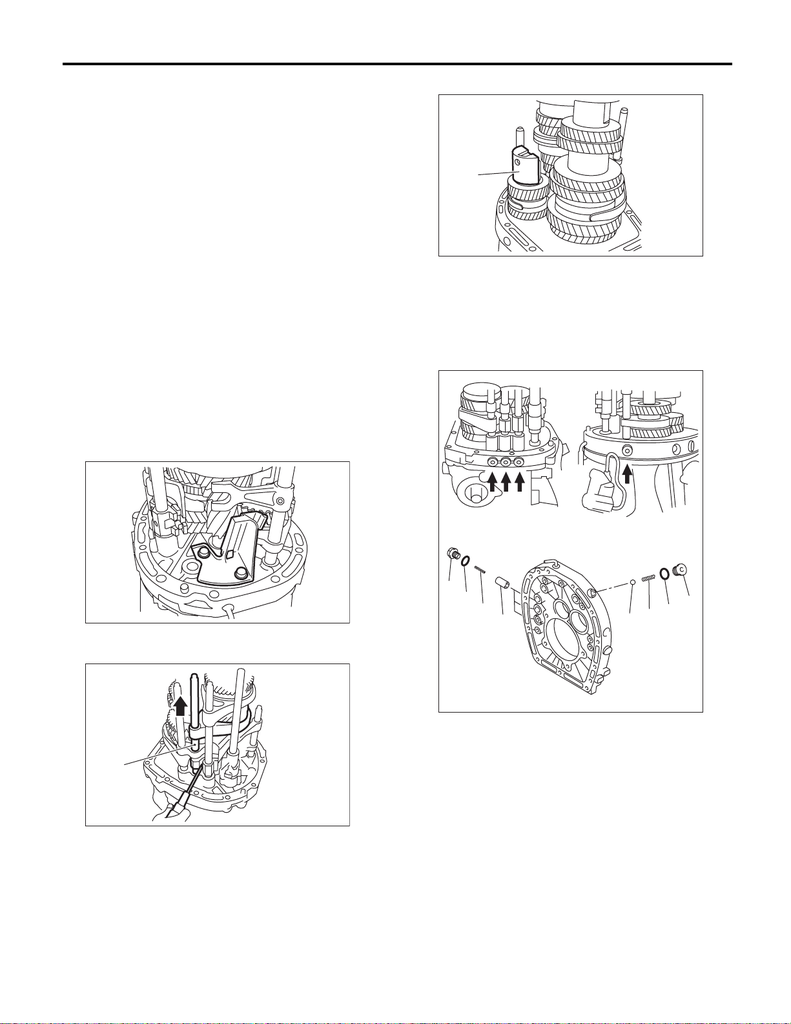

6MT(TY85)-63

Main Shaft Assembly

MANUAL TRANSMISSION AND DIFFERENTIAL

19.Main Shaft Assembly

A: REMOVAL

1) Remove the manual transmission assembly

from the vehicle. <Ref. to 6MT(TY85)-31, REMOV-

AL, Manual Transmission Assembly.>

2) Prepare the transmission for overhaul. <Ref. to

6MT(TY85)-38, Preparation for Overhaul.>

3) Remove the neutral position switch, back-up

light switch and harness. <Ref. to 6MT(TY85)-41,

REMOVAL, Neutral Position Switch.> <Ref. to

6MT(TY85)-40, REMOVAL, Back-up Light

Switch.>

4) Remove the extension case. <Ref. to

6MT(TY85)-42, REMOVAL, Extension Case.>

5) Remove the transfer driven gear. <Ref. to

6MT(TY85)-54, REMOVAL, Transfer Driven

Gear.>

6) Remove the center differential. <Ref. to

6MT(TY85)-56, REMOVAL, Center Differential.>

7) Remove the transmission case. <Ref. to

6MT(TY85)-57, REMOVAL, Transmission Case.>

8) Remove the striking rod.

9) Remove the oil guide B.

10) Use a screwdriver to shift to the 4th gear posi-

tion.

11) Remove the reverse idler holder.

12) Remove the check plug, O-ring, check spring,

plunger and check ball from the adapter plate.

NOTE:

Do not reuse the O-ring.

(A) 3rd-4th fork rod

MT-01623

MT-01736

(A)

(A) Reverse idler holder

(A) Check plug

(B) O-ring

(C) Checking spring

(D) Plunger

(E) Check ball

MT-00544

(A)

(D)

(E)

(A)

(A)

(B)

(B)

(C)

(C)

MT-01931

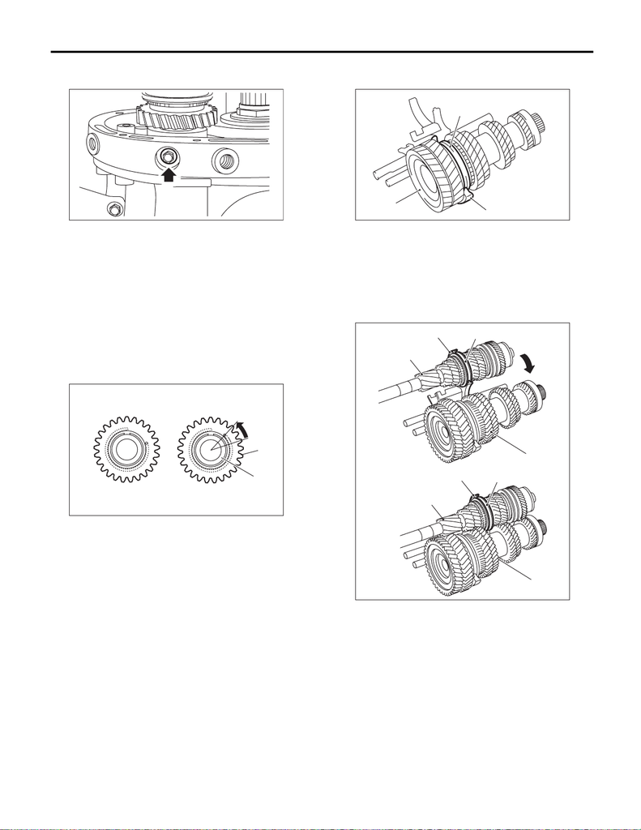

6MT(TY85)-64

Main Shaft Assembly

MANUAL TRANSMISSION AND DIFFERENTIAL

13) Remove the bolt and gasket holding the re-

verse idler gear shaft.

14) Push the main shaft assembly, driven gear as-

sembly, reverse idler gear and shifter forks to re-

move from the adapter plate all at once.

NOTE:

A helper is required to perform this work.

B: INSTALLATION

1) Adjust the 3rd-4th and 5th-6th fork rods. <Ref. to

6MT(TY85)-110, ADJUSTMENT, Shifter Fork and

Rod.>

2) Rotate the reverse idler sub gear in the arrow di-

rection by two teeth, and secure it with a wire.

3) Attach the driven gear assembly to the 1st-2nd

shifter fork assembly.

4) Attach the main shaft assembly to the 3rd-4th

shifter fork, and assemble to the driven gear as-

sembly.

(A) Free status

(B) Set status

(C) Reverse idler sub gear

(D) Reverse idler gear

MT-00546

MT-02684

(C)

(A)

(B)

(D)

(A) 1st-2nd shifter fork

(B) Driven gear ASSY

(C) 1st-2nd coupling sleeve

(A) 3rd-4th shifter fork

(B) 3rd-4th coupling sleeve

(C) Driven gear ASSY

(D) Main shaft ASSY

MT-00548

(A)

(B)

(C)

MT-00549

(C)

(A)

(B)

(C)

(D)

(D)

(A)

(B)

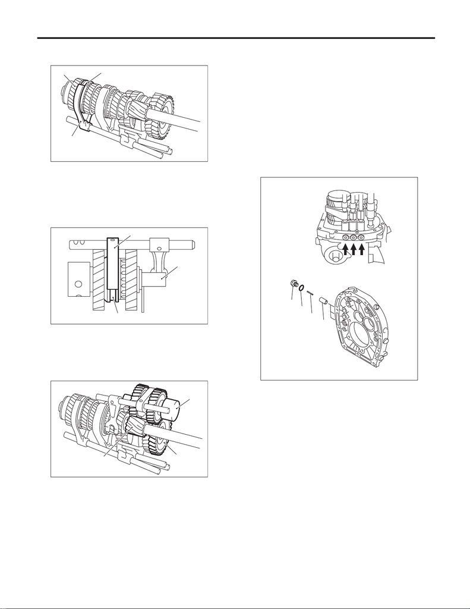

6MT(TY85)-65

Main Shaft Assembly

MANUAL TRANSMISSION AND DIFFERENTIAL

5) Attach the 5th-6th shifter fork assembly to the

main shaft assembly.

6) Attach the reverse shifter fork assembly to the

reverse idler gear assembly.

7) Install the reverse idler gear assembly.

8) Install the thrust bearing of the driven gear as-

sembly.

9) Push on the shifter forks, main shaft assembly,

driven gear assembly and reverse idler gear as-

semblies, to attach to the adapter plate all at once.

NOTE:

A helper is required to perform this work.

10) As necessary, remove the wire used to secure

from the reverse idler gear.

11) Install the plunger, check spring, new O-ring

and check plugs.

Tightening torque:

25 N·m (2.5 kgf-m, 18.4 ft-lb)

(A) 5th-6th shifter fork

(B) 5th-6th coupling sleeve

(C) Main shaft ASSY

(A) Reverse idler gear ASSY

(B) Reverse shifter fork

(C) Reverse sleeve

(A) Reverse idler gear ASSY

(B) 1st drive gear

(C) Reverse gear (driven shaft)

MT-00550

(B)

(A)

(C)

MT-00551

(A)

(B)

(C)

MT-00552

(B)

(A)

(C)

(A) Check plug

(B) O-ring

(C) Checking spring

(D) Plunger

MT-01932

(D)

(A)

(B)

(C)

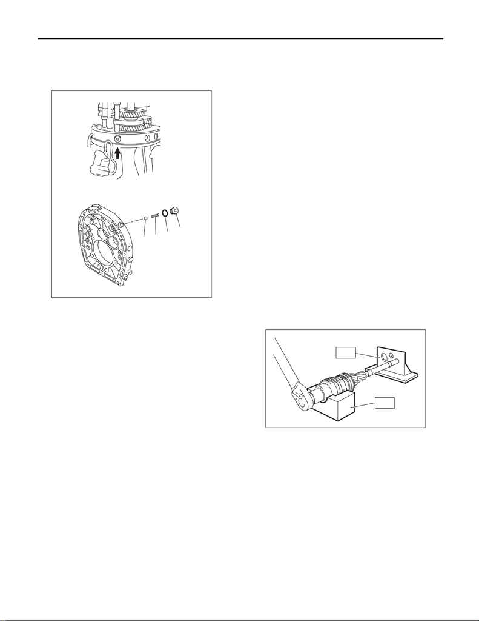

6MT(TY85)-66

Main Shaft Assembly

MANUAL TRANSMISSION AND DIFFERENTIAL

12) Install the check ball, check spring, new O-ring

and check plugs.

Tightening torque:

25 N·m (2.5 kgf-m, 18.4 ft-lb)

13) Install the bolt and a new gasket holding the re-

verse idler shaft.

Tightening torque:

25 N·m (2.5 kgf-m, 18.4 ft-lb)

14) Use a screwdriver to shift to the 4th gear posi-

tion.

15) Install the reverse idler holder.

16) Install the oil guide B.

Tightening torque:

18 N·m (1.8 kgf-m, 13.3 ft-lb)

17) Install the striking rod.

18) Install the transmission case. <Ref. to

6MT(TY85)-59, INSTALLATION, Transmission

Case.>

19) Install the selected main shaft snap ring and

washers.

20) Install the center differential. <Ref. to

6MT(TY85)-56, INSTALLATION, Center Differen-

tial.>

21) Install the transfer driven gear. <Ref. to

6MT(TY85)-54, INSTALLATION, Transfer Driven

Gear.>

22) Install the extension case. <Ref. to 6MT(TY85)-

42, INSTALLATION, Extension Case.>

23) Install the neutral position switch, back-up light

switch and harness. <Ref. to 6MT(TY85)-41, IN-

STALLATION, Neutral Position Switch.> <Ref. to

6MT(TY85)-40, INSTALLATION, Back-up Light

Switch.>

24) Install the manual transmission assembly to the

vehicle. <Ref. to 6MT(TY85)-33, INSTALLATION,

Manual Transmission Assembly.>

C: DISASSEMBLY

NOTE:

Individual coupling sleeves and synchronizer hubs

meet at a specified position. Before disassembly,

mark the meeting position of the coupling sleeve

and synchronizer hub.

1) Affix the ST to the work table.

ST 18664AA000 BASE

2) Flatten the tab of the lock nut.

3) Set the main shaft assembly to the ST, and re-

move the lock nut and lock washer.

ST1 18665AA000 HOLDER

ST2 18664AA000 BASE

NOTE:

Use a 38 mm socket wrench.

(A) Check plug

(B) O-ring

(C) Checking spring

(D) Check ball

MT-00554

(D)

(A)

(B)

(C)

MT-00556

ST2

ST1

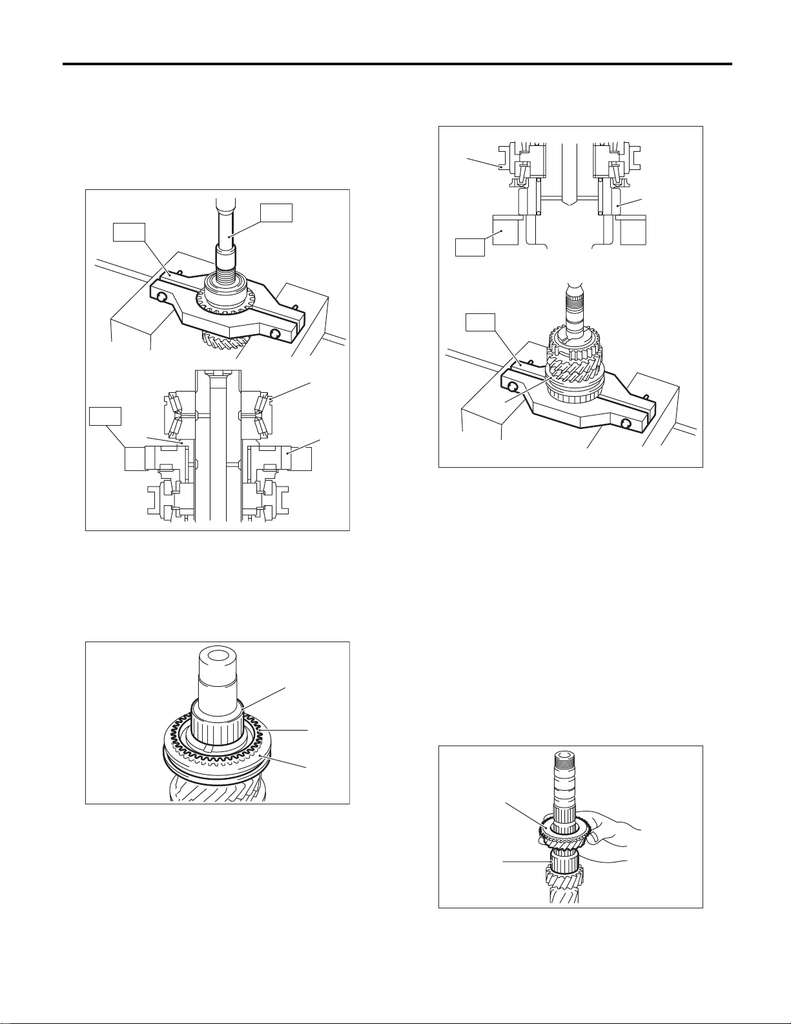

6MT(TY85)-67

Main Shaft Assembly

MANUAL TRANSMISSION AND DIFFERENTIAL

4) Remove the main shaft assembly from the ST.

5) Set the ST1 to the 6th drive gear, and use a

press to remove the double taper roller bearing and

outer race, 6th drive gear bushing and 6th drive

gear.

ST1 18722AA010 REMOVER

ST2 899864100 REMOVER

6) Remove the 5th-6th coupling sleeve, needle

bearing and 6th baulk ring.

7) Set the ST to the 3rd drive gear, and use a press

to remove individual parts.

ST 18720AA000 REMOVER

D: ASSEMBLY

NOTE:

When replacing the following parts, replace as a

set.

• Coupling sleeve and synchronizer hub

• 3rd outer baulk ring, 3rd synchro cone and 3rd in-

ner baulk ring

• Double taper roller bearing

1) Apply adequate transmission gear oil to the main

shaft, needle bearing and 3rd drive gear inner sur-

face.

2) Install the needle bearing and 3rd drive gear to

the main shaft.

(A) Double taper roller bearing

(B) 6th drive gear bushing

(C) 6th drive gear

(A) Needle bearing

(B) 6th baulk ring

(C) 5th-6th coupling sleeve

MT-00557

(A)

(B)

(C)

ST1

ST2

ST1

(A)

(B)

(C)

MT-00558

(A) 3rd drive gear

(B) 3rd-4th coupling sleeve

(A) 3rd drive gear

(B) Needle bearing

(A)

ST

(B)

(B)

ST

MT-01406

MT-00560

(A)

(B)

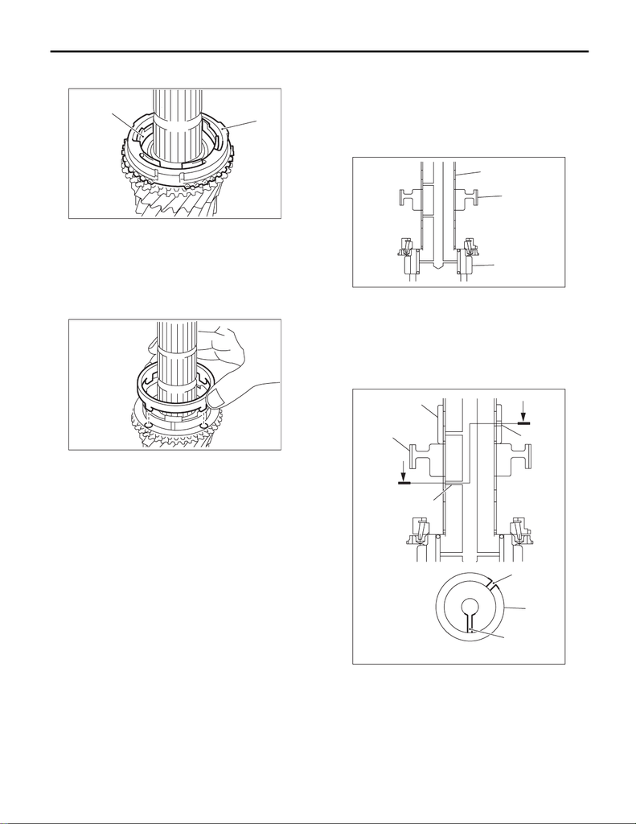

6MT(TY85)-68

Main Shaft Assembly

MANUAL TRANSMISSION AND DIFFERENTIAL

3) Install the 3rd inner baulk ring, 3rd synchro cone

and 3rd outer baulk ring.

NOTE:

Install the 3rd synchro cone by aligning the protru-

sion of the 3rd synchro cone with the hole on the

3rd drive gear.

4) Install the 3rd-4th synchronizer hub and 4th nee-

dle bearing race.

CAUTION:

Apply transmission gear oil onto sliding or re-

volving surfaces before installation.

(1) Being careful of the install direction of the

3rd-4th synchronizer hub, set to the main shaft.

(2) With the main shaft oil hole and 4th needle

bearing race oil hole out of alignment, attach to

the main shaft.

(A) 3rd inner baulk ring

(B) 3rd outer baulk ring

(A)

(B)

MT-00561

MT-01501

(A) Main shaft

(B) 3rd-4th synchronizer hub

(C) 3rd drive gear

(A) 4th needle bearing race

(B) 3rd-4th synchronizer hub

(C) 4th needle bearing race oil hole

(D) Main shaft oil hole

MT-00884

(A)

(B)

(C)

MT-01819

(A)

(B)

A

(D)

(C)

A

A - A

(C)

(D)

(A)

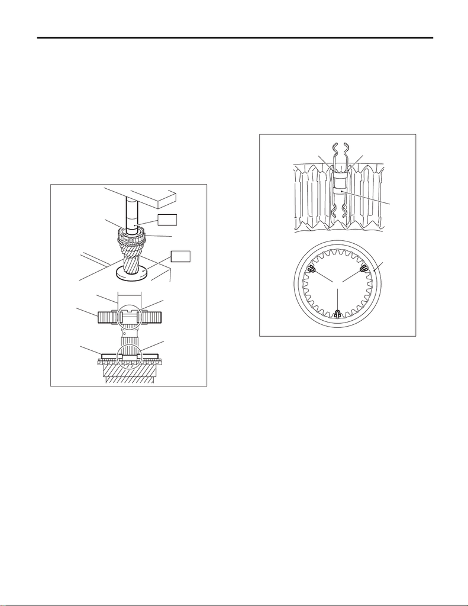

6MT(TY85)-69

Main Shaft Assembly

MANUAL TRANSMISSION AND DIFFERENTIAL

(3) Using the ST, push in to the 3rd-4th syn-

chronizer hub and 4th needle bearing race all at

once.

ST1 18651AA000 INSTALLER

ST2 398177700 INSTALLER

CAUTION:

Do not apply pressure in excess of 40 kN (4.0

ton, 4.4 US ton, 3.9 Imp ton).

NOTE:

When pushing into the 3rd-4th synchronizer hub

and 4th needle bearing race, move the 3rd outer

baulk ring to match the protrusion of the 3rd outer

baulk ring and the cut out of the 3rd-4th synchroniz-

er hub.

5) Make sure that the 3rd drive gear can be turned

smoothly by hand. If it does not turn smoothly, re-

assemble.

6) Attach the 3rd-4th shifting insert at the appropri-

ate position of the 3rd-4th coupling sleeve.

NOTE:

• The location angle of each shifting insert is 120°.

• Refer to the following figure to install the shifting

insert.

(A) 3rd-4th synchronizer hub

(B) 3rd outer baulk ring

(C) Cut out of the 3rd-4th synchronizer hub

(D) Protrusion of the 3rd outer baulk ring

(E) 4th needle bearing race

MT-03196

(D)

(C)

(E)

(A)

(B)

(A)

(E)

ST1

ST2

(A) Attach the straight part of the shifting insert to

the sleeve convex portion.

(B) 3rd-4th shifting insert

(C) 3rd-4th coupling sleeve

(B)

(C)

MT-01820

(A)

(B)

(A)

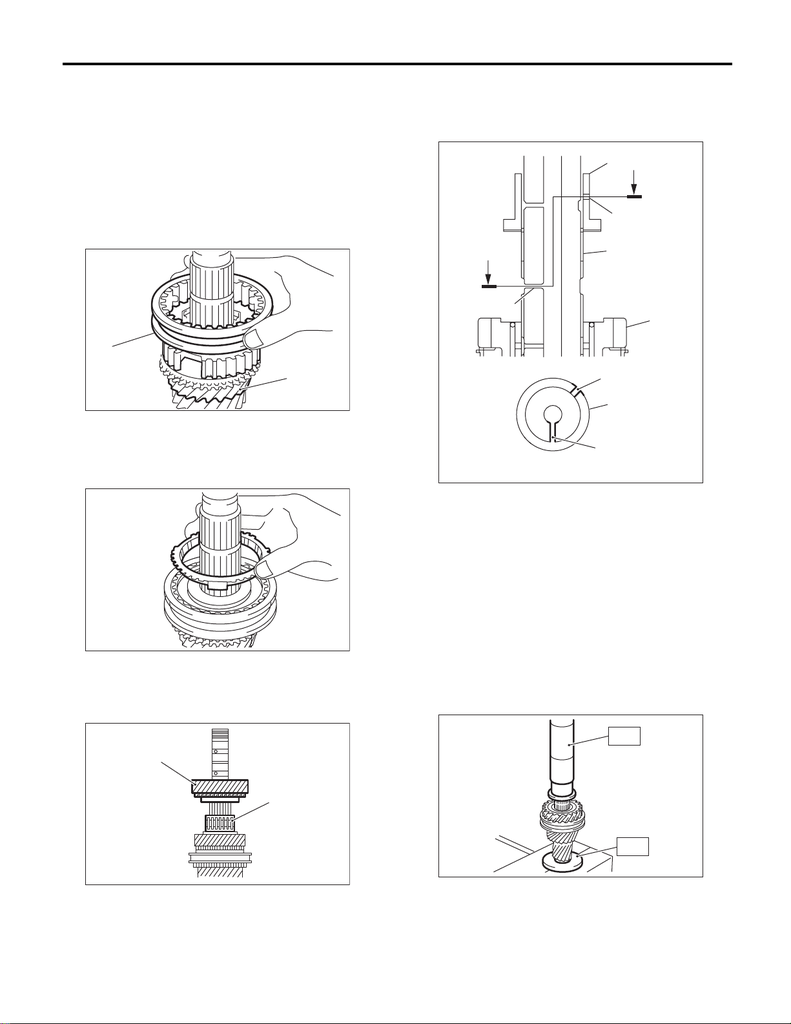

6MT(TY85)-70

Main Shaft Assembly

MANUAL TRANSMISSION AND DIFFERENTIAL

7) Attach the 3rd-4th coupling sleeve to the 3rd-4th

synchronizer hub.

CAUTION:

Apply transmission gear oil onto sliding or re-

volving surfaces before installation.

NOTE:

• There is an identification groove on the 3rd-4th

coupling sleeve.

• Place the groove towards the 3rd drive gear, and

attach the 3rd-4th coupling sleeve.

8) Install the 4th baulk ring.

9) Apply adequate transmission gear oil to the main

shaft, needle bearing and 4th drive gear inner sur-

face.

10) Install the needle bearing and 4th drive gear.

11) Install the 5th drive gear bushing.

(1) With the main shaft oil hole and 5th drive

gear bushing oil hole out of alignment, attach to

the main shaft.

(2) Using the ST, push into the 5th drive gear

bushing.

ST1 18651AA000 INSTALLER

ST2 398177700 INSTALLER

CAUTION:

Do not apply pressure in excess of 40 kN (4.0

ton, 4.4 US ton, 3.9 Imp ton).

12) Make sure that the 4th drive gear can be turned

smoothly by hand. If it does not turn smoothly, re-

assemble.

(A) 3rd drive gear

(B) 3rd-4th sleeve identification groove (1)

(A) Needle bearing

(B) 4th drive gear

MT-00563

(A)

(B)

MT-00564

MT-00565

(A)

(B)

(A) 5th drive gear bushing

(B) Main shaft oil hole

(C) Main shaft

(D) 5th drive gear bushing oil hole

(E) 4th drive gear

MT-01821

(A)

A

(D)

(C)

(E)

(B)

A

(D)

(A)

A - A

(B)

MT-00567

ST1

ST2

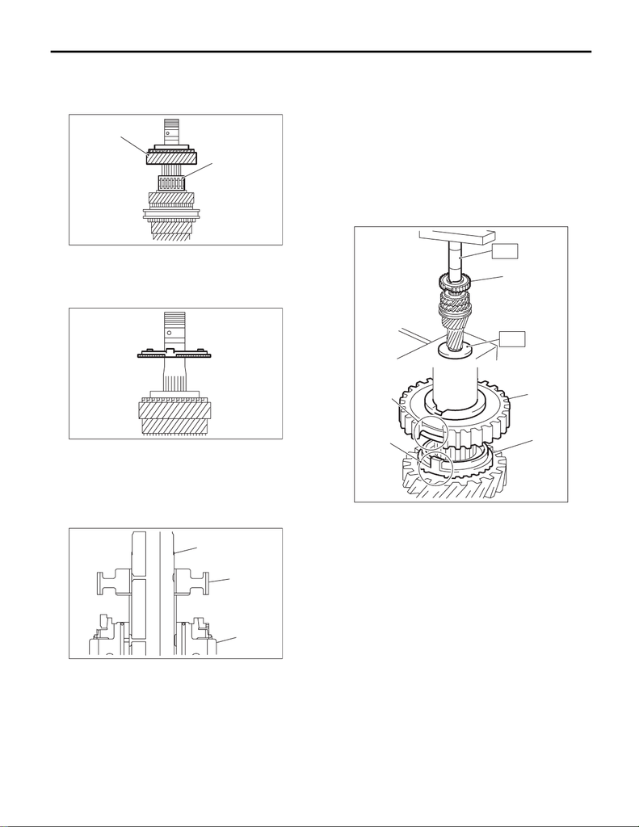

6MT(TY85)-71

Main Shaft Assembly

MANUAL TRANSMISSION AND DIFFERENTIAL

13) Apply adequate transmission gear oil to the

main shaft, needle bearing and 5th drive gear inner

surface.

14) Install the needle bearing and 5th drive gear.

15) Install the 5th baulk ring.

16) Install the 5th-6th synchronizer hub.

CAUTION:

Apply transmission gear oil onto sliding or re-

volving surfaces before installation.

(1) Being careful of the install direction of the

5th-6th synchronizer hub, set to the main shaft.

(2) Using the ST, push into the 5th-6th synchro-

nizer hub.

ST1 18651AA000 INSTALLER

ST2 398177700 INSTALLER

CAUTION:

Do not apply pressure in excess of 40 kN (4.0

ton, 4.4 US ton, 3.9 Imp ton).

NOTE:

When pushing into the 5th-6th synchronizer hub,

move the 5th outer baulk ring to match the protru-

17) Make sure that the 5th drive gear can be turned

smoothly by hand. If it does not turn smoothly, re-

assemble.

(A) Needle bearing

(B) 5th drive gear

(A) Main shaft

(B) 5th-6th synchronizer hub

(C) 5th drive gear

MT-00568

(A)

(B)

MT-00569

MT-00570

(A)

(B)

(C)

(A) 5th-6th synchronizer hub

(B) 5th outer baulk ring

(C) Cut out of the 5th-6th synchronizer hub

(D) Protrusion of the 5th outer baulk ring

MT-00571

(D)

(C)

(B)

(A)

(A)

ST1

ST2

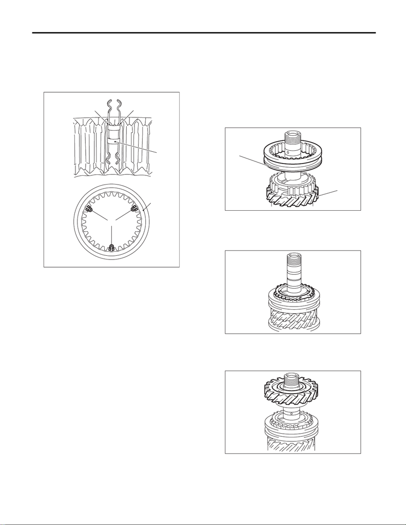

6MT(TY85)-72

Main Shaft Assembly

MANUAL TRANSMISSION AND DIFFERENTIAL

18) Attach the 5th-6th shifting insert at the appro-

priate position of the 5th-6th coupling sleeve.

NOTE:

• The location angle of each shifting insert is 120°.

• Refer to the following figure to install the shifting

insert key.

19) Attach the 5th-6th coupling sleeve to the 5th-

6th synchronizer hub.

CAUTION:

Apply transmission gear oil onto sliding or re-

volving surfaces before installation.

NOTE:

• There are two identification grooves on the 5th-

6th sleeve.

• Place the grooves towards the 5th drive gear,

and attach the 5th-6th coupling sleeve.

20) Install the 6th baulk ring.

21) Apply adequate transmission gear oil to the

main shaft, 6th needle bearing and 6th drive gear

inner surface.

22) Install the 6th drive gear.

(A) Attach the straight part of the shifting insert to

the sleeve convex portion.

(B) 5th-6th shifting insert

(C) 5th-6th sleeve

(B)

(C)

MT-01820

(A)

(B)

(A)

(A) 5th drive gear

(B) 5th-6th coupling sleeve identification groove (2)

MT-00572

(A)

(B)

MT-00573

MT-00574

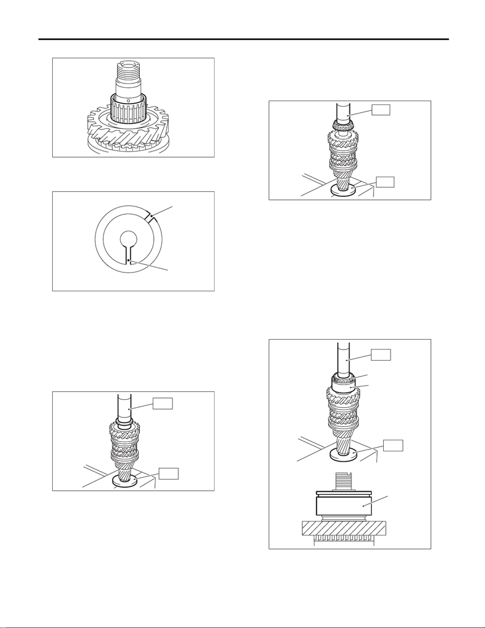

6MT(TY85)-73

Main Shaft Assembly

MANUAL TRANSMISSION AND DIFFERENTIAL

23) Install the 6th needle bearing.

24) With 6th drive gear bushing oil hole and the

main shaft oil hole out of alignment, attach to the

main shaft.

25) Using the ST, install the 6th drive gear bushing.

ST1 18651AA000 INSTALLER

ST2 398177700 INSTALLER

CAUTION:

Do not apply pressure in excess of 40 kN (4.0

ton, 4.4 US ton, 3.9 Imp ton).

26) Make sure that the 6th drive gear can be turned

smoothly by hand. If it does not turn smoothly, re-

assemble.

27) Using the ST, install the double taper roller

bearing inner race (front side).

ST1 18651AA000 INSTALLER

ST2 398177700 INSTALLER

CAUTION:

Do not apply pressure in excess of 40 kN (4.0

ton, 4.4 US ton, 3.9 Imp ton).

NOTE:

Use a new double taper roller bearing.

28) Using the ST, install the outer race and inner

race (rear side) of the double taper roller bearing.

ST1 18651AA000 INSTALLER

ST2 398177700 INSTALLER

CAUTION:

Do not apply pressure in excess of 40 kN (4.0

ton, 4.4 US ton, 3.9 Imp ton).

NOTE:

• Confirm that the outer race and inner race are in-

stalled in the proper direction.

• Push in until there is no backlash on the double

taper roller bearing outer race and the bearing

turns smoothly by hand.

(A) 6th drive gear bushing oil hole

(B) Main shaft oil hole

MT-00575

MT-01933

(B)

(A)

MT-00577

ST1

ST2

(A) Double taper roller bearing outer race

(B) Double taper roller bearing inner race (rear

side)

MT-00578

ST1

ST2

MT-00579

(B)

(A)

(A)

ST2

ST1

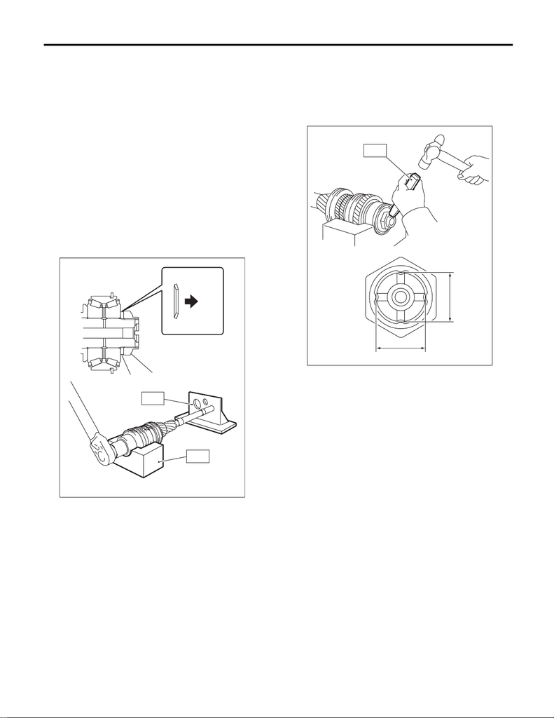

6MT(TY85)-74

Main Shaft Assembly

MANUAL TRANSMISSION AND DIFFERENTIAL

29) Make sure that the double taper roller bearing

turns smoothly by hand. If it does not turn smoothly,

replace the double taper roller bearing as a set, and

reassemble.

30) Attach a new lock washer and a new lock nut.

CAUTION:

Apply transmission gear oil to the lock washer

and lock nut before installation.

31) Set the main shaft assembly to the ST, and

tighten the lock nut.

ST1 18665AA000 HOLDER

ST2 18664AA000 BASE

NOTE:

Make sure the lock washer is installed in the proper

direction.

Tightening torque:

392 N·m (40.0 kgf-m, 289.1 ft-lb)

32) Using the ST, crimp the lock nut in 4 locations,

with dimensions within A 27±0.3 mm (1.06±0.01

in).

ST 18668AA000 PUNCH

NOTE:

Do not damage the crimp area of the lock nut.

(A) Lock washer

(B) Lock nut

(C) Nut side

MT-02714

ST2

ST1

(B)

(A)

(C)

MT-00580

A

A

ST

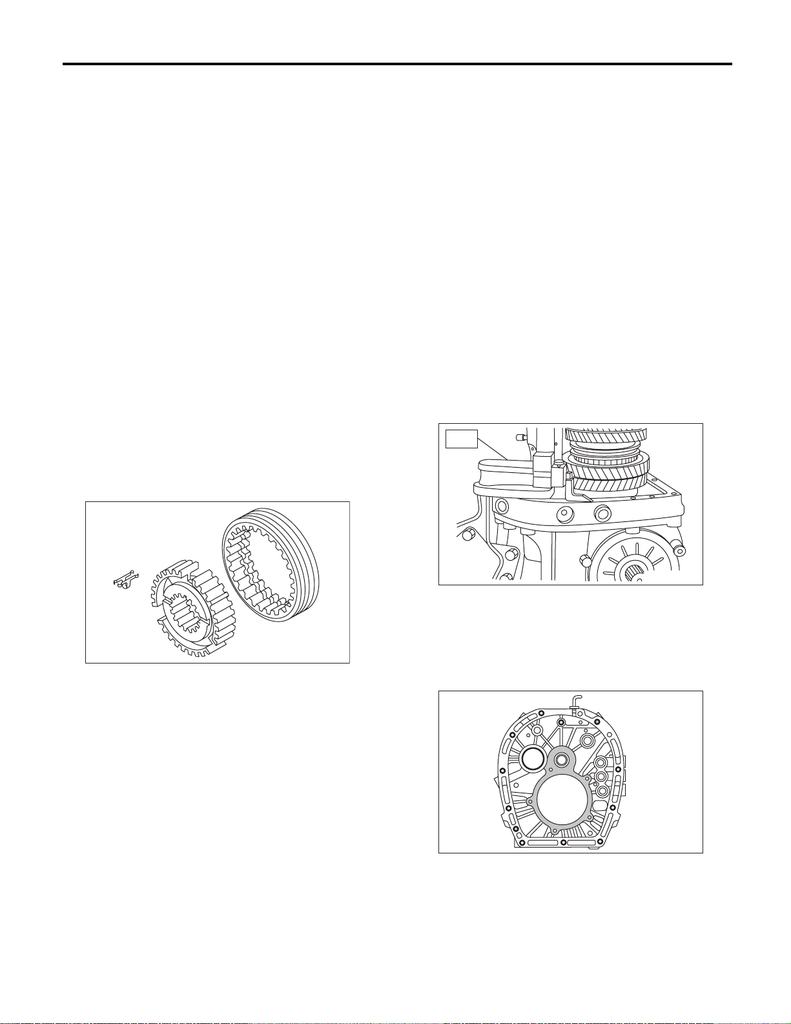

6MT(TY85)-75

Main Shaft Assembly

MANUAL TRANSMISSION AND DIFFERENTIAL

E: INSPECTION

Disassembled parts should be washed with clean-

ing solvent first, then inspected carefully.

1) Bearing

Replace the bearings in the following cases.

• Wear, rusting or damage of the bearings

• The bearing does not rotate smoothly or an ab-

normal noise is emitted when turning.

• The bearing has other defects.

2) Bushing (each gear)

Replace the bushing in following cases.

• The sliding surface is damaged or abnormally

worn.

3) Gear

Replace gears in the following cases.

• The gear teeth surface is damaged or excessive-

ly worn.

• The contact area of the baulk ring is damaged.

• The inner face of the gear is worn.

4) Baulk ring, synchro cone

Replace the baulk ring and synchro cone in the fol-

lowing cases.

• Wear, rusting or damage of the baulk ring

5) Shifting insert

Replace the shifting insert if deformed, excessively

worn or defective in any way.

F: ADJUSTMENT

1. MAIN SHAFT SNAP RING & ADJUSTING

WASHER SELECTION

NOTE:

In the following conditions, perform the procedures

below.

• 1st to 6th driven gear replacement

• 1st and 2nd synchro ring assembly replacement

• Ball bearing replacement

• Adapter plate replacement

• Driven shaft replacement

1) Insert the drive pinion assembly into the adapter

plate.

NOTE:

Confirm that the thrust bearing outer race has not

been removed and the drive pinion is not lifted.

2) Set the height gauge to the adapter plate. Lower

the height gauge indicator to the mating surface of

the adapter plate and case, and set to zero points.

ST 18853AA000 HEIGHT GAUGE

NOTE:

• The adapter plate will be the base point for the

measurement. Use a scraper to remove any gasket

material remaining on the end face.

• During measurement, do not place the height

gauge in the shaded area shown in the figure.

MT-00581

MT-00582

ST

MT-00583

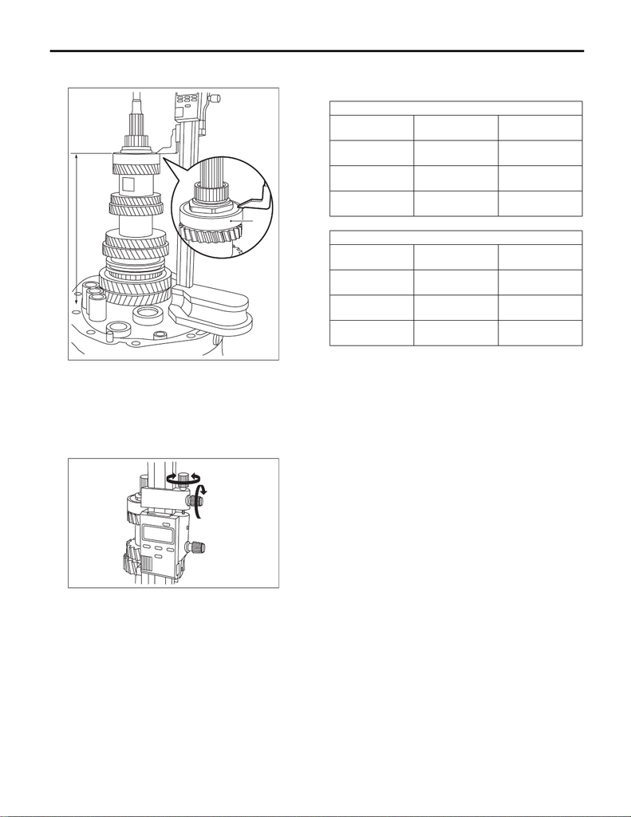

6MT(TY85)-76

Main Shaft Assembly

MANUAL TRANSMISSION AND DIFFERENTIAL

3) Measure the height to the ball bearing end face

(height H).

NOTE:

Set the height gauge indicator near the measure-

ment target, and lock dial (1) as shown in the figure.

Turn dial (2), and set the indicator to the end face of

the bearing.

value.

4) According to the measurement value, select the

snap ring and adjusting washer from the following

table.

(A) Ball bearing

(A)

MT-00955

H

MT-00585

(2)

(1)

Snap ring

H: mm (in) Part No.

Thickness: mm

(in)

270.83 — 271.40

(10.66 — 10.69)

805072010

1.65

(0.065)

271.41 — 271.98

(10.69 — 10.71)

805072011

1.95

(0.077)

271.99 — 272.56

(10.71 — 10.73)

805072012

2.25

(0.089)

Adjusting washer

H: mm (in) Part No.

Thickness: mm

(in)

270.83 — 271.40

(10.66 — 10.69)

803067012

1.6

(0.063)

271.41 — 271.98

(10.69 — 10.71)

803067011

1.3

(0.051)

271.99 — 272.56

(10.71 — 10.73)

803067010

1.0

(0.039)